# Using Your University OpenAI ChatGPT Account and Microsoft Copilot with Office 365

12:15–1:15 PM  
Zoom: https://csueb.zoom.us/j/88674490934  
Slides produced with the help of OpenAI Codex.

Eric A. Suess

October 22, 2026

## Today’s goals

By the end of this session, you should be able to:

- Sign in to the correct university AI workspace.
- Explain what **context** means for a large language model.
- Choose between Microsoft Copilot and OpenAI ChatGPT for a task.
- Find Copilot Library and Teach.
- Distinguish ChatGPT **Chat**, **Work**, and **Sites**.
- Use an interactive visualization to explore a statistical idea.

## Two institutional accounts

You may have access to two separate AI ecosystems:

| University account | Main environment | Typical strengths |
| --- | --- | --- |
| [OpenAI ChatGPT](https://chatgpt.com/) | ChatGPT web and desktop app | Conversation, analysis, content creation, Projects, Work, Codex, Sites |
| [Microsoft Copilot](https://m365.cloud.microsoft/chat) | Microsoft 365 with direct access to Word, Excel, and PowerPoint | Word, Excel, PowerPoint, Outlook, Teams, and OneDrive |

Access depends on university licensing, your role, and administrator settings.

## Start with the correct identity

1. Use your university email to sign in to [ChatGPT](https://chatgpt.com/) or [Microsoft Copilot](https://m365.cloud.microsoft/chat).
2. Complete institutional SSO and multifactor authentication.
3. Check the account name and active workspace after signing in.
4. Keep personal and university workspaces separate.

**Tip**

Signing in successfully does not guarantee that every advertised feature is enabled for your university account.

## University account ≠ API account

- A university ChatGPT account can provide access to ChatGPT and Codex.
- An OpenAI **API key** belongs to an API project with separate billing and limits.
- ChatGPT subscription access does not automatically fund an API project.
- Most students and instructors should begin with browser or desktop sign-in.

The same general distinction applies between a licensed Microsoft 365 account and separately billed developer services.

## What is an LLM?

A large language model predicts and generates language from:

- Your instructions
- The information currently available to it
- Patterns learned during training
- Results returned by tools it is allowed to use

It does not automatically know your course, files, definitions, or intended audience.

## What is context?

**Context is the working information available to the model for the current task.**

Context can include:

- Your current prompt and earlier messages
- Uploaded files, images, tables, and data
- Project or workspace instructions
- Connected documents and authorized services
- Search results, calculations, and other tool output

Context changes what the model can reasonably produce.

## Context as conditioning information

Conditional probability asks how probabilities change when information is known.

$$P(\text{next token} \mid \text{current context})$$

- The context supplies the information after the conditioning bar.
- Different context changes the probabilities of possible continuations.
- Each generated token becomes context for predicting the next token.

For example, “A right angle contains 90 …” makes **degrees** more probable, while “The lecture hall contains 90 …” makes **students** more probable.

## Context changes the answer

Changing the context changes the conditional distribution of possible responses.

**Weak context**

> Explain the mean.

**Useful context**

> Explain the sample mean to students in an introductory statistics course. Use five quiz scores, show the calculation, distinguish a sample statistic from a population parameter, and end with one check-for-understanding question.

The second prompt identifies the audience, topic boundary, example, terminology, and desired output.

## Context is not the same as memory

| Concept | Purpose |
| --- | --- |
| Context | Working information available for this task or conversation |
| Memory | Information retained for possible use in later conversations |
| Project | Related chats, files, and instructions organized around ongoing work |
| Connected source | Authorized information retrieved from another service |

Context has limits. Start a new conversation for a new outcome, and restate critical requirements when necessary.

## A practical context checklist

Before sending a substantial prompt, provide:

- **Goal:** What should be accomplished?
- **Audience:** Who will use the result?
- **Sources:** Which files or information should be used?
- **Constraints:** What must be included or avoided?
- **Format:** What should the finished result look like?
- **Verification:** What should be checked before completion?

Only include information that your university permits you to share.

## Microsoft Copilot with Office 365

Signing in to [Microsoft Copilot](https://m365.cloud.microsoft/chat) with your university email gives you direct access to:

- **Word** for documents
- **Excel** for workbooks
- **PowerPoint** for presentations
- **Apps** for additional tools, including **Forms** and **Learning**

Copilot can also support work involving:

- Outlook messages and calendars
- Teams meetings and conversations
- OneDrive and SharePoint files

The exact Copilot features you see depend on your university license, account permissions, and administrator settings.

Sources: [Copilot Chat in Microsoft 365 apps](https://support.microsoft.com/en-us/microsoft-365-copilot/how-copilot-chat-works-in-microsoft-365-apps) and [Microsoft Copilot setup](https://learn.microsoft.com/copilot/microsoft-365/microsoft-365-copilot-setup)

## Microsoft Copilot Library

**Library** is a visual hub for finding supported content created with Copilot.

- Return to Copilot-generated images and Pages.
- Find supported items shared with you.
- Filter content by type.
- Reopen work for review, reuse, or collaboration.

Library helps answer: **“Where did the thing Copilot created go?”**

Source: [Get started with Microsoft Copilot Library](https://support.microsoft.com/en-us/microsoft-365-copilot/get-started-with-microsoft-365-copilot-library)

## Teach in Microsoft Copilot

**Teach** gives eligible educators guided tools for creating and revising instructional materials:

- Lesson plans
- Quizzes and rubrics
- Flashcards
- Reading-level and difficulty adjustments
- Standards-aligned materials

Teach is intended for eligible faculty and staff with Microsoft 365 Education licensing. It may not appear for student accounts.

Source: [Teach in the Microsoft 365 Copilot App](https://support.microsoft.com/en-US/education/teach-in-the-microsoft-365-copilot-app)

## Copilot add-ons and Copilot Studio

**Add-ons extend Copilot with specialized agents, knowledge, and tools.**

- **Find agents:** Open **All Agents**, review an agent, and select **Add** or **Request approval**.
- **Copilot Studio:** Build and customize agents with instructions for a specific task.
- **Knowledge sources:** Give an agent approved course documents or SharePoint content to use when answering questions.
- **Tools and connectors:** Connect an agent to other services to retrieve information or perform actions.

**Teaching example:** Build a course FAQ agent that answers from your syllabus and approved course materials.

Available agents, connections, and publishing options depend on university licensing, permissions, and administrator settings.

Sources: [Add agents to Copilot](https://support.microsoft.com/en-us/microsoft-365-copilot/get-more-agents-in-the-microsoft-365-copilot-app) and [Extend agents with Copilot Studio](https://learn.microsoft.com/en-us/microsoft-copilot-studio/extend-agent-capabilities)

## Exercise: Copilot lesson prompt

Run this prompt in Microsoft Copilot:

> Create a 50-minute introductory statistics lesson on the Law of Large Numbers. Include learning objectives, a coin-flip activity, three check-for-understanding questions, and an exit ticket. Write for students who know the sample mean but have not studied probability limits.

After reviewing the result:

1. Ask Copilot to revise the reading level or difficulty.
2. Move suitable content into Word or PowerPoint.
3. Find generated Pages or images in Library.

## Exercise: Copilot in Outlook

Open Outlook and use Copilot instead of searching your mail by hand:

1. Ask Copilot to list your unanswered emails from the last 7 days.
2. Pick one and ask Copilot to draft the reply.
3. Read the draft carefully: check names, dates, and commitments.
4. Send it only if you approve it.

**Tip**

You are responsible for anything you send. If Copilot does not appear in Outlook, note what you see instead.

Sources: [Triage email with Copilot](https://support.microsoft.com/en-us/office/triage-email-with-microsoft-365-copilot-in-outlook-85932469-7c3f-4a6a-acdb-adf0f3ebc169) and [Draft an email with Copilot](https://support.microsoft.com/en-us/office/draft-an-email-message-with-copilot-in-outlook-3eb1d053-89b8-491c-8a6e-746015238d9b)

## OpenAI ChatGPT: Chat or Work?

| Choose | When you want | Examples |
| --- | --- | --- |
| **Chat** | A question or back-and-forth conversation | Explain, brainstorm, compare, summarize, revise |
| **Work** | A larger task carried through to a reviewable result | Analyze files, create a deck, draft a report, build a project plan |

Chat helps you think through something. Work is designed around a defined outcome and may plan steps, gather context, and use approved tools.

Source: [Use ChatGPT](https://learn.chatgpt.com/docs/use-chatgpt)

## ChatGPT projects preserve shared context

A project can keep related materials together:

- Chats
- Uploaded files
- Project instructions
- Connected sources

Use one project for an ongoing body of work, but start a separate chat for each distinct outcome. Chat and Work conversations can live in the same project.

Source: [Projects and chats](https://learn.chatgpt.com/docs/projects)

## ChatGPT Sites

**Sites** lets ChatGPT create, refine, host, and share:

- Websites
- Interactive explanations
- Small web applications
- Games and teaching tools

Sites is in public beta and is available on eligible plans, including Edu. Availability, publishing, and sharing can be controlled by university administrators.

Source: [ChatGPT Sites](https://learn.chatgpt.com/docs/sites)

## Check your ChatGPT usage

1. Click the **CSU East Bay icon** at the **bottom-left** of the ChatGPT window.
2. Select **Settings > Usage**.
3. Review your **5-hour limit** and **weekly limit**, including the usage remaining and reset times shown.
4. Click the **Analytics** tab at the top to see **monthly utilization** of the different **models and tools**.

Use this view to understand your usage and plan larger tasks around the limits shown for your university account.

Sources: University workspace navigation described for this session; [OpenAI usage limits](https://learn.chatgpt.com/docs/pricing) and [Settings > Usage](https://learn.chatgpt.com/docs/sign-in-with-chatgpt).

## From explanation to interactive experience

A useful progression is:

1. Ask in **Chat** for an explanation.
2. Use **Work** when you want a complete teaching artifact.
3. Use **`/visualize`** in Chat or Work when interaction improves understanding.
4. Turn the result into a **Site** when it should have a durable, shareable web address.

Always review the content, calculations, controls, links, and sharing settings before publishing.

## Visualization demonstration

In a **Chat or Work** conversation, type:

```
/visualize the Law of Large Numbers
```

Ask for controls that change the population distribution, sample size, and random seed.

Source: [OpenAI Visualizations](https://learn.chatgpt.com/docs/visualizations)

## What should the visualization show?

For independent observations $X_1, X_2, \ldots$, the running sample mean is

$$\bar{X}_n = \frac{1}{n}\sum_{i=1}^{n} X_i.$$

Under appropriate conditions, $\bar{X}_n$ approaches the population mean $\mu$ as $n$ grows.

The visualization should make the early variability and later stabilization visible—without suggesting that the running mean moves smoothly or monotonically.

## A reproducible R example

**Show the R code**

```r
library(tidyverse)

set.seed(310)

lln_data <- tibble(
  n = 1:500,
  observation = rnorm(500, mean = 50, sd = 10),
  running_mean = cummean(observation)
)

lln_data |>
  ggplot(aes(x = n, y = running_mean)) +
  geom_line(color = "#1f77b4", linewidth = 0.8) +
  geom_hline(
    yintercept = 50,
    color = "#c23b22",
    linetype = "dashed",
    linewidth = 0.8
  ) +
  labs(
    x = "Number of observations",
    y = "Running sample mean",
    caption = "Dashed line: population mean = 50"
  ) +
  theme_minimal(base_size = 16)
```

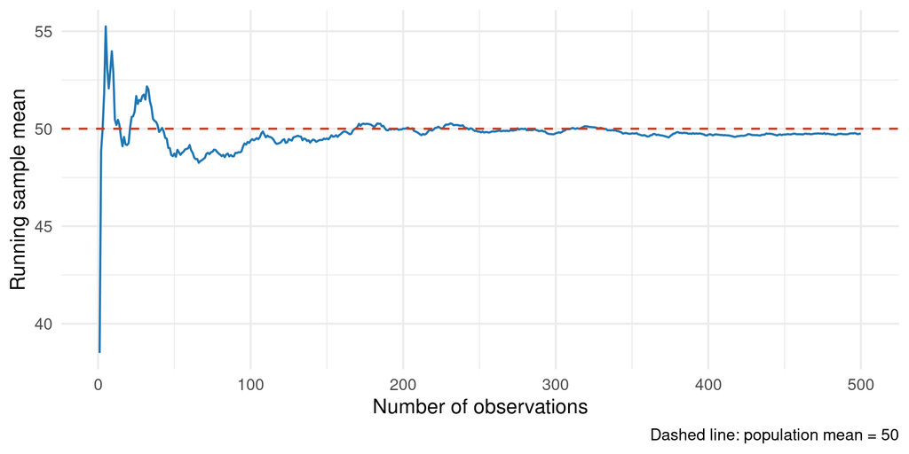

Figure 1

## A reproducible Python example

**Show the Python code**

```python
import numpy as np
import matplotlib.pyplot as plt

rng = np.random.default_rng(310)

n = np.arange(1, 501)
observations = rng.normal(loc=50, scale=10, size=500)
running_mean = np.cumsum(observations) / n

fig, ax = plt.subplots(figsize=(10, 5))
ax.plot(n, running_mean, color="#1f77b4", linewidth=1.5)
ax.axhline(
    y=50,
    color="#c23b22",
    linestyle="--",
    linewidth=1.5
)
ax.set_xlabel("Number of observations")
ax.set_ylabel("Running sample mean")
ax.grid(color="#dddddd", linewidth=0.8)
ax.spines[["top", "right"]].set_visible(False)
fig.text(0.98, 0.01, "Dashed line: population mean = 50", ha="right")
fig.tight_layout(rect=(0, 0.04, 1, 1))
plt.show()
```

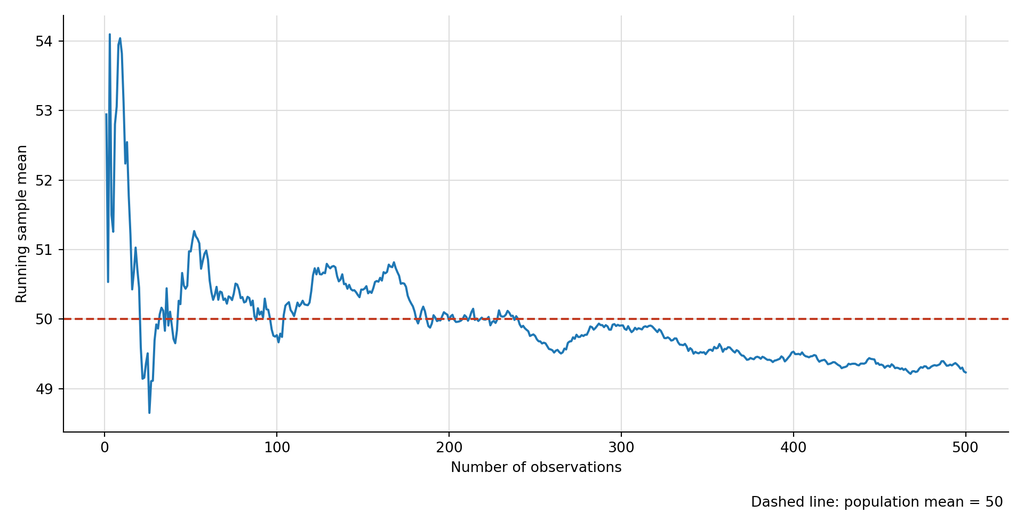

Figure 2

## Fortran 95 computation + ggplot2

Fortran 95 computes the running means; R imports the results and ggplot2 draws the plot.

**Show the Fortran 95 code**

```fortran
subroutine lln_running_mean_f95(n, running_mean)
  implicit none

  integer, intent(in) :: n
  double precision, intent(out) :: running_mean(n)
  integer, parameter :: int64 = selected_int_kind(18)
  integer(kind=int64), parameter :: multiplier = 16807_int64
  integer(kind=int64), parameter :: modulus = 2147483647_int64
  integer(kind=int64) :: state
  double precision :: observation, total, uniform_value
  integer :: i

  state = 310_int64
  total = 0.0d0

  do i = 1, n
    state = mod(multiplier * state, modulus)
    uniform_value = dble(state) / dble(modulus)
    observation = 50.0d0 + sqrt(12.0d0) * 10.0d0 * &
                  (uniform_value - 0.5d0)
    total = total + observation
    running_mean(i) = total / dble(i)
  end do
end subroutine lln_running_mean_f95
```

**Show the R compile, import, and plot code**

```r
library(tidyverse)

build_dir <- file.path(tempdir(), "talk01-f95")
dir.create(build_dir, showWarnings = FALSE, recursive = TRUE)
copied <- file.copy(
  c("lln_running_mean.f95", "Makevars.f95"),
  build_dir,
  overwrite = TRUE
)
stopifnot(all(copied))

shared_library <- local({
  previous_dir <- setwd(build_dir)
  on.exit(setwd(previous_dir), add = TRUE)

  compile_log <- system2(
    file.path(R.home("bin"), "R"),
    c("CMD", "SHLIB", "lln_running_mean.f95"),
    env = paste0(
      "R_MAKEVARS_USER=",
      file.path(build_dir, "Makevars.f95")
    ),
    stdout = TRUE,
    stderr = TRUE
  )

  library_path <- file.path(
    build_dir,
    paste0("lln_running_mean", .Platform$dynlib.ext)
  )
  stopifnot(file.exists(library_path))
  normalizePath(library_path)
})

dyn.load(shared_library)

n <- 500L
f95_result <- .Fortran(
  "lln_running_mean_f95",
  n = n,
  running_mean = double(n)
)

f95_plot_data <- tibble(
  n = seq_len(n),
  running_mean = f95_result$running_mean
)

f95_plot_data |>
  ggplot(aes(x = n, y = running_mean)) +
  geom_line(color = "#1f77b4", linewidth = 0.8) +
  geom_hline(
    yintercept = 50,
    color = "#c23b22",
    linetype = "dashed",
    linewidth = 0.8
  ) +
  labs(
    x = "Number of observations",
    y = "Running sample mean",
    caption = "Dashed line: population mean = 50"
  ) +
  theme_minimal(base_size = 16)
```

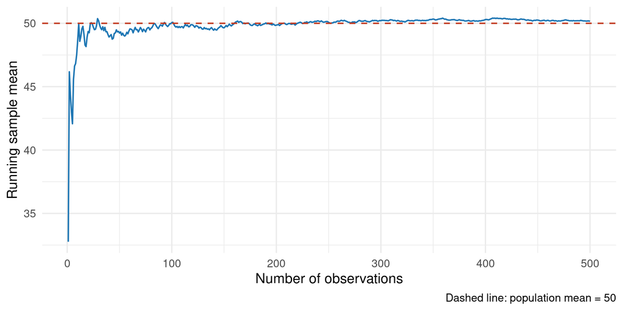

Figure 3

## Compare the two assistants

Use the same prompt in ChatGPT and Microsoft Copilot:

> Explain the Law of Large Numbers to an introductory statistics student. Include a concrete example, one common misconception, and two questions students can use to check their understanding.

Compare:

- Accuracy and clarity
- Use of sources or citations
- Ease of revision
- Integration with your files and applications
- Where the generated result is stored

## Context activity

Revise this underspecified prompt:

> Make a presentation about averages.

Add the following forms of context:

1. Audience and prior knowledge
2. Learning goal
3. Source material
4. Number and style of slides
5. Required example or activity
6. Verification criteria

Then compare the original and revised outputs.

## Protect university information

- Do not paste passwords, API keys, session tokens, or recovery codes into a prompt.
- Do not upload grades, student identifiers, or restricted research data unless specifically approved.
- Connected tools use the permissions of the signed-in account.
- Review sharing settings before distributing generated Pages, documents, or Sites.
- Follow university policy even when a feature is technically available.

Institutional protections help, but they do not replace judgment about what should be shared.

## Verify AI-generated work

Before using or sharing a result:

- Check factual claims against reliable sources.
- Recalculate important numerical results.
- Open and test generated files, links, and controls.
- Inspect citations to confirm that they exist and support the claim.
- Revise language for the actual audience.
- Record where AI materially contributed when required.

## Key takeaways

- Context is the working information available to the model.
- The correct university account determines available features and protections.
- Copilot Library helps you return to generated content.
- Teach provides guided instructional-material tools for eligible educators.
- Chat supports conversation; Work carries larger tasks toward a deliverable.
- Sites turns suitable work into a hosted experience.
- Verification and responsible data handling remain human responsibilities.

## References

All links were accessed October 2, 2026.

- OpenAI: [Use ChatGPT](https://learn.chatgpt.com/docs/use-chatgpt), [Projects and chats](https://learn.chatgpt.com/docs/projects), [Visualizations](https://learn.chatgpt.com/docs/visualizations), [Sites](https://learn.chatgpt.com/docs/sites), and [ChatGPT Work cloud security](https://learn.chatgpt.com/docs/enterprise/chatgpt-work-cloud-security)
- Microsoft: [Copilot in Microsoft 365 apps](https://support.microsoft.com/en-us/microsoft-365-copilot/how-copilot-chat-works-in-microsoft-365-apps), [Copilot setup](https://learn.microsoft.com/copilot/microsoft-365/microsoft-365-copilot-setup), [Copilot Library](https://support.microsoft.com/en-us/microsoft-365-copilot/get-started-with-microsoft-365-copilot-library), [Teach](https://support.microsoft.com/en-US/education/teach-in-the-microsoft-365-copilot-app), [Copilot Chat FAQ](https://learn.microsoft.com/copilot/edpfaq), and [Copilot security for education](https://learn.microsoft.com/en-us/microsoft-365/education/guide/1-reference/configure-microsoft-copilot-security-education)

Product availability varies by account, license, platform, region, rollout stage, and university administrator settings.

## Questions and discussion

What would you like to try with your university AI accounts?

**Join the Discussion**

**Date:** October 22, 2026  
**Time:** 12:15 – 1:15 PM  
**Zoom:** https://csueb.zoom.us/j/88674490934